# Advanced A/B Testing

6/16/2019

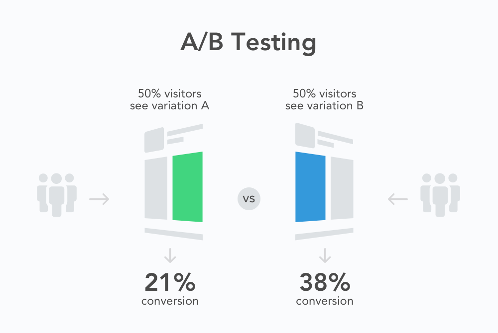

Source: splitmetrics.com

## Example A/B test

[figure not shown]

1. Randomly assign customers to treatments
2. Measure response(s)
3. Compare groups to determine how the treatment changes response

Source: Optimizely Blog

## Why A/B tests work

By **randomizing** over a large number of customers, we create groups that are the same, on average.

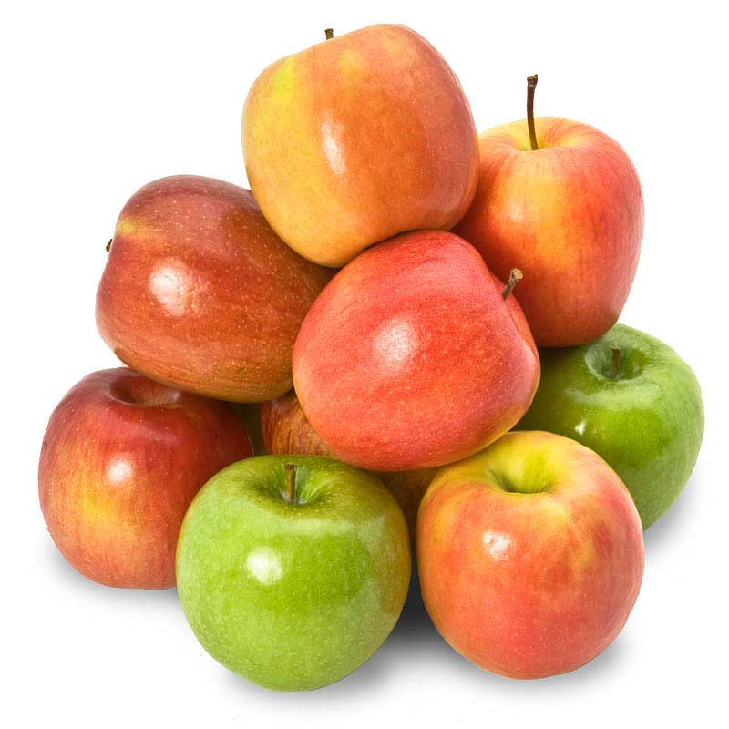

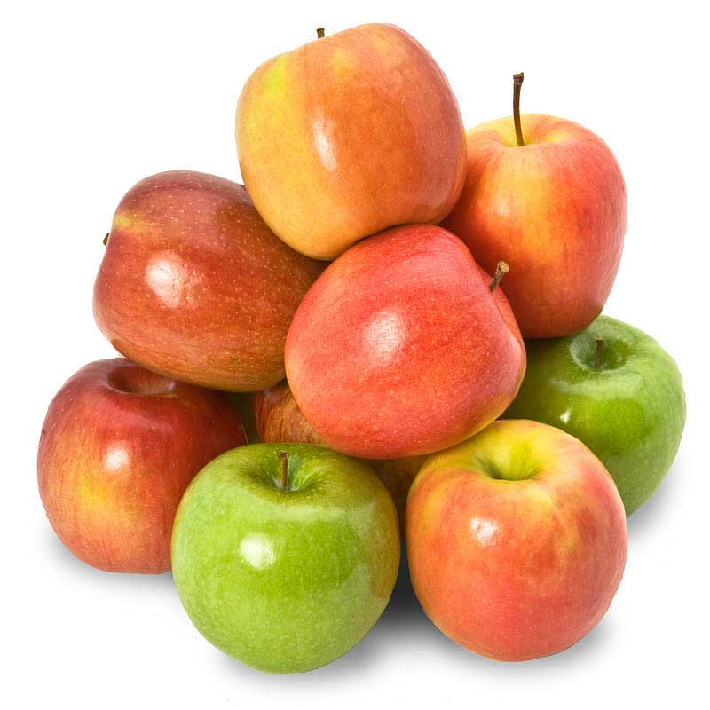

Any behavioral differences between these groups is **caused by the treatments** we randomly assigned.

1, 2, 3. Repeat with me. Randomization will set you free.

## Workshop plan

- Test Analysis Basics
  - Randomization checks
  - Analysis
  - Sample size planning
- When your sample size is big
  - Slice and dice
  - Uplift modeling
  - Causal forests
- When your sample size is small
  - Pre-test matching
  - Post-stratification
- Maximizing profits
  - Test & roll
  - Multi-armed bandits
- When you can’t randomize (time permitting)

## About Elea McDonnell Feit

- Professor at Drexel University
  - Teach data-driven digital marketing and marketing experiments
  - Develop new marketing analytics tools
    - [Measuring Multi-Channel Advertising Response](https://pubsonline.informs.org/doi/abs/10.1287/mnsc.2016.2451)
    - [Test & Roll: Profit-Maximizing A/B Tests](https://papers.ssrn.com/sol3/papers.cfm?abstract_id=3274875)
  - Make analytics accessible to practitioners
    - [R for Marketing Research and Analytics](http://r-marketing.r-forge.r-project.org/)
- Previously
  - General Motors
  - The Modellers
  - Wharton Customer Analytics

## Materials

Slides and code at https://eleafeit.github.io/ab_test/.

R Markdown source is at https://github.com/eleafeit/ab_test/.

## How to use the materials

We will walk through a set of examples that I created using the R (a statistical programming language).

- **If you don’t know R**, let me drive the R syntax so that you can focus on where we are going. Download the slides and follow along.
- **If you are learning R**, you should also let me drive. I can answer some R syntax questions along the way, but I don’t want to get stuck in the syntatical mud. The code will be there later when you want to review.
- **If you know R well**, download the RMarkdown files and run the code as we go along.

I’m adaptable. Please ask questions so I can calibrate.

## Let’s go!

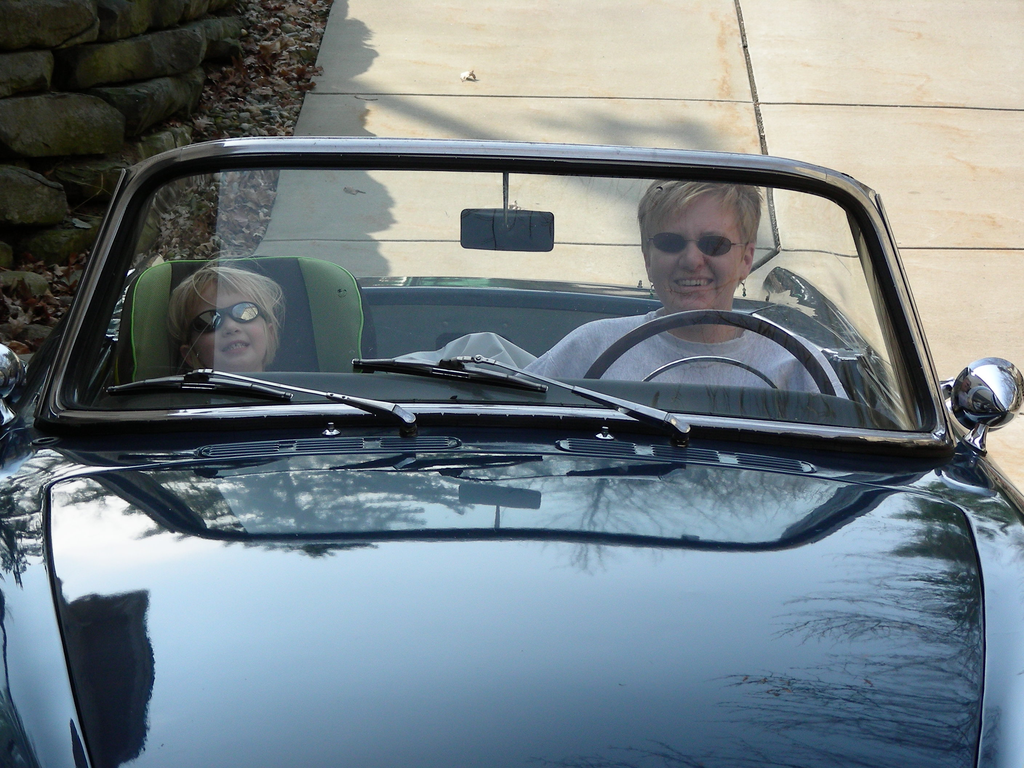